# Home Exam

Data Wrangling and Visualization with Tidyverse

Author

Termeh Shafie

# Instructions

The home exam consists of two parts (30% + 40%). For each part, answer the questions posed and solve the tasks. 10% of the marks are assigned to the structure and organization of your report.

Note that there may be more than one way to solve the task, the only requirement is that Tidyverse tools are used in the majority of your executions.

**Important**:

- You should submit your work as an html file with resources embedded. Failure to upload a complete html file or a file in a different format means your submission will not be marked.
- Always include your code chunks that solved the tasks. Failure to do so will lead to significantly reduced marks.
- Since the readability and structure of your report is also marked, a tip is that you exclude messages and warnings when showing output. Also, refrain from including output with many rows.

**Deadline: 26.07.2024 at 23:59**

# Part I: Bike rentals in DC

Bike sharing systems are new generation of traditional bike rentals where whole process from membership, rental and return back has become automatic. Through these systems, user is able to easily rent a bike from a particular position and return back at another position. Currently, there are about over 500 bike-sharing programs around the world which is composed of over 500 thousands bicycles. Today, there exists great interest in these systems due to their important role in traffic, environmental and health issues.

Apart from interesting real world applications of bike sharing systems, the characteristics of data being generated by these systems make them attractive for the research. Opposed to other transport services such as bus or subway, the duration of travel, departure and arrival position is explicitly recorded in these systems. This feature turns bike sharing system into a virtual sensor network that can be used for sensing mobility in the city. Hence, it is expected that most of important events in the city could be detected via monitoring these data.

## Data

The data used for this part is called `dcbikeshare` and available with this exam. You can also download the data from the below website (you will then need the daily data). All information needed about the data and its variables are provided in the below link.

Source: [UCI Machine Learning Repository - Bike Sharing Dataset](http://archive.ics.uci.edu/ml/datasets/Bike+Sharing+Dataset)

## Tasks

### Data cleaning and visualization (30%)

1. Re-code the `season` variable to be a factor with meaningful level names as outlined in the codebook, with spring as the baseline level. (3%)
2. Recode the binary variables `holiday` and `workingday` to be factors with levels no (0) and yes (1), with no as the baseline level.(3%)
3. Recode the `yr` variable to be a factor with levels 2011 and 2012, with 2011 as the baseline level.(3%)
4. Recode the `weathersit` variable as 1 - clear, 2 - mist, 3 - light precipitation, and 4 - heavy precipitation, with clear as the baseline.(3%)
5. Calculate raw temperature, feeling temperature, humidity, and windspeed as their values given in the dataset multiplied by the maximum raw values stated in the codebook for each variable. Instead of writing over the existing variables, create new ones with concise but informative names.(3%)
6. Check that the sum of `casual` and `registered` adds up to `cnt` for each record.(3%)
7. Recreate the following visualization, and interpret it in context of the data. **Hint:** You will need to use one of the variables you created above. The temperature plotted is the feeling temperature. (6%)

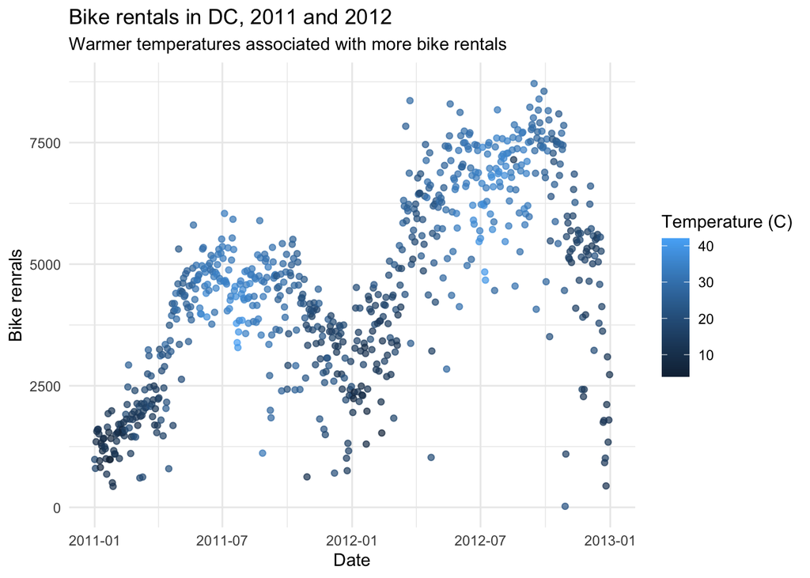

8. Create a visualization displaying the relationship between bike rentals and season. Interpret the plot in context of the data. (6%)

# Part II: Money in Politics

Every election cycle brings its own brand of excitement – and lots of money. Political donations are of particular interest to political scientists and other researchers studying politics and voting patterns. They are also of interest to citizens who want to stay informed of how much money their candidates raise and where that money comes from.

In the United States, *“only American citizens (and immigrants with green cards) can contribute to federal politics, but the American divisions of foreign companies can form political action committees (PACs) and collect contributions from their American employees.”*

In this part, we will scrape and work with data foreign connected PACs that donate to US political campaigns. First, we will get data foreign connected PAC contributions in the 2022 election cycle. Then, you will use a similar approach to get data such contributions from previous years so that we can examine trends over time.

## Data

For this part of the exam, you are going to be scraping the data using `rvest`. However, if you fail to do so, I have made a dataset available for you to use so that you still can complete the following tasks provided. In that case, you only perform tasks 2- 6 below.

## Tasks

### Data collection via web scraping (10%)

The data come from [OpenSecrets.org](https://www.opensecrets.org), a *“website tracking the influence of money on U.S. politics, and how that money affects policy and citizens’ lives”*. This website is hosted by The Center for Responsive Politics, which is a nonpartisan, independent nonprofit that *“tracks money in U.S. politics and its effect on elections and public policy.”*

Your goal is to scrape data for contributions in all election years Open Secrets has complete data for which is 2000-2022. Since that means repeating a task many times, it’s better to first write a function that works on the first page, and then iterate it over pages for all years.

1. Complete the following scraping tasks. As a guide for these tasks, I have provided an R script called `scrape-pac.R`. Once the code works, include the code in your Quarto/R Markdown file with argument `eval = FALSE`.
- Check that a bot has permissions to access pages on this domain.
- Write a function called `scrape_pac()` that scrapes information from the Open Secrets webpage for foreign-connected PAC contributions in a given year [from here](https://www.opensecrets.org/political-action-committees-pacs/foreign-connected-pacs/). This function should:
  1. have one input: the URL of the webpage and should return a data frame.
  2. rename variables scraped, using `snake_case` naming.
  3. clean up the `Country of Origin/Parent Company` variable with `str_squish()`.
  4. add a new column to the data frame for `year`. We will want this information when we ultimately have data from all years, so this is a good time to keep track of it. Our function doesn’t take a year argument, but the year is embedded in the URL, so we can extract it out of there, and add it as a new column. Use the `str_sub()` function to extract the last 4 characters from the URL. You will probably want to look at the help for this function to figure out how to specify “last 4 characters”.

Below some hints are given to step by step:

- Define the URLs for 2022, 2020, and 2000 contributions. Then, test your function using these URLs as inputs. Does the function seem to do what you expected it to do?
- Construct a vector called `urls` that contains the URLs for each webpage that contains information on foreign-connected PAC contributions for a given year.
- Map the `scrape_pac()` function over `urls` in a way that will result in a data frame called `pac_all`. How many observations and variables do you have in this data frame? Use inline code to answer.
- Save the data as a file called `pac-all.csv` so that you can import it for solving the below tasks.

## Data cleaning (10%)

Read in the data `pac-all.csv`.

2. Separate the `country_parent` into two such that country and parent company appear in different columns for country-level analysis. (3%)
3. Convert contribution amounts in `total`, `dems`, and `repubs` from character strings to numeric values. (3%)
4. Remove the character strings including `$` and `,` signs in the `total`, `dems`,and `repubs` columns and convert these columns to numeric. End your code chunk by printing out the top 10 rows of your data frame (if you just type the data frame name it should automatically do this for you). (4%)

## Data visualization and interpretation (20%)

5. Create a line plot of total contributions from all foreign-connected PACs in the Canada and Mexico over the years. Once you have made the plot, write a brief interpretation of what the graph reveals (10%).
6. Recreate the following visualization. Once you have made the plot, write a brief interpretation of what the graph reveals. Note that these are only German contributions. You will need to make use of functions from the **scales** package for axis labels as well as from **ggplot2**.(10%)

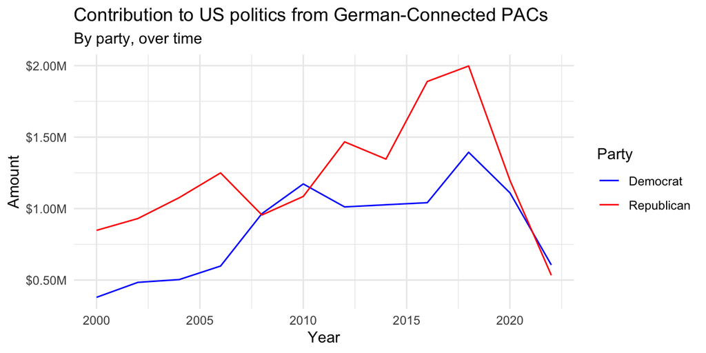